[output not shown]

In the last few years, numerous civil disputes worldwide, which might threaten American interests and human rights, have spurred considerable debate over American military intervention. In fact, throughout history, nations were periodically faced with choices about a declaration of war. Over the past two decades, the U.S. and its allies have faced a variety of international threats and difficulties including possible nuclear weapons, hostile/unfriendly nations such as Iran, and human rights abuses and genocide in Sudan and other nations. Despite declines in legislative control of foreign policy, the U.S. Congress still plays an important role in deciding how the military is used by retaining the rights to formally declare war, limit the use of military force, and control military appropriations [@Phelps2002]. Previous research examined the predictors of presidential use of military force [@Clark2005; @Keller2012] and predictors of public support for war [@Cohrs2002; @Friese2009; @McCleary2009]. However, the predictors of legislative support of military action have been understudied, thus, presenting an interesting opportunity for exploration [@Kriner2014]. In this study, we sought to determine predictors of congressional support of military action by using language as a predictor which is a common measure in studies of politics [@Blaxill2013; @Crew2011; @Jarvis2004; @Slatcher2007] and conflict [@Kriner2014; @Leudar2004; @Pennebaker2011]. Furthermore, we explored if the most basic and objective components of language, word frequencies, could be used as practical predictors of support of conflict.

## Politics and Content

A wide variety of predictor and outcome measures have been previously examined to determine the role of the executive in conflict. @Clark2005 focused on political factors influencing the probability that an executive in a democracy would engage in conflict and found that low levels of citizen political participation, opposing party majority in the legislature, and greater legislative control of foreign policy was associated with lower probability that the executive would engage in conflict. @Keller2012 used leadership trait analysis, which is a content analytic method developed by @Hermann2005, to classify executives’ leadership style based on their language patterns and to examine how U.S. presidents’ locus of control related to their willingness to use military force abroad to divert attention from domestic problems. Keller and Foster found that presidents high in internal locus of control were more likely to engage military forces internationally and this relationship was mediated by domestic factors, such as the gross domestic product (GDP), indicating these presidents could use international conflict as a diversionary tactic. @Leudar2004 used membership categorization analysis, which examines how people use words to identify with groups as well as to orient to events, in an exploration of how George W. Bush, Tony Blair, and Osama bin Laden used language to frame the events surrounding 9/11 and to orient to future action. All three leaders used language to set up an us versus them dichotomy, distinguishing allies and enemies; Bush and Blair used political and moral language to accomplish this separation, while bin Laden used religious language.

Turning to research on public opinion, @Cohrs2002 conducted a study in Germany examining predictors of students’ attitudes toward the war in Kosovo, and they found militarism, diffuse political support, and authoritarianism predicted support for the war. They also found some evidence of confirmation bias whereas those who were against the war sought out information to strengthen that belief. @McCleary2009 found similar results in a study of U.S. college students regarding support for the war in Iraq, and they found that blind patriotism (conceptually similar to diffuse political support), militarism, and concern for national security predicted continuing support for the war. A different study by @Friese2009 found that political orientation predicted support for conflict in Iraq, but this relationship was mediated by attributions of responsibility for the war such that those who believed or were led to believe that U.S. leaders lied about weapons of mass destruction had much less support for the war.

Both the role of the legislative in conflict and individual word frequencies have been underexplored in their relationship to military conflict. @Kriner2014 studied speeches pertaining to the course of the Iraq War in the House of Representatives and found that antiwar rhetoric by Democrats increased as the number of casualties in the war increased, and specifically, the number of casualties from representatives’ districts. A speech was coded as antiwar if it argued that the initial invasion was a mistake or that troops should be withdrawn; for instance, if the congressman discussed causalities as unacceptably high or argued that the invasion was unjustified as Saddam Hussein posed no immediate threat, that speech was coded as antiwar. Furthermore, number of casualties also predicted antiwar voting by Democrats, and antiwar rhetoric by representatives was positively correlated with antiwar attitudes held by their constituents. In examining war discourse, Kriner and Shen only surveyed whether the overall content of each speech was prowar or antiwar not the specifics of the language used. @Brett2007 examined individual word use but focused on resolutions in business conflicts. They found that greater use of negative emotion words, such as hurt or hate, and command words, such as ought or must, decreased the likelihood of conflict resolution while greater use of causal words, such as because or hence, and inhibition words, such as constrain or stop, increased the likelihood of conflict resolution. The current study combines these ideas by using the focus of the @Kriner2014 study, war rhetoric in Congress, and the methods of the @Brett2007 study with word frequencies as predictors.

## Language Analysis

Discourse is the fusion of content and style words. Within any given sample of language, content words answer the question of what is being said, while style words answer the question of how it is being said. Content words include mostly nouns, verbs, and adjectives, and style words include mostly pronouns, prepositions, articles, conjunctions, negations, and quantifiers [@Pennebaker2011]. The Linguistic Inquiry and Word Count [LIWC; @Pennebaker2007] is a program developed to summarize these words and others broken down into 82 language categories. Besides style words, the LIWC measures constructs including: a) cognitive mechanisms, such as *know*, *because*, and *none* reflecting causation, exclusivity, and certainty, b) social and emotional words, which include words reflecting social processes and positive and negative emotion, c) relativity, such as *go*, *down*, and *until* reflecting motion, space, and time, d) and personal concerns, which include words reflecting achievement, money, death, and religion among others. Discourse analysis has become a popular trend to understand psychological correlates tied to language. @Tausczik2010 reviewed over 100 articles that used language as a basis for studying other constructs; specifically, these studies investigated how categories in the LIWC are related to psychological phenomena, such as attention, emotionality, dominance, and deception.

## Attentional Focus

Just as a person’s gaze can illuminate where their attention is so can the words they use. Specifically, pronouns and verb tense can demonstrate attentional focus by indicating who or what someone is attending to in a situation and how they are processing the situation. Therefore, greater use of first person pronouns indicated a self focus, third person pronouns indicated a focus on others, and verb tense indicated whether the focus was on past, present, or future events [@Tausczik2010]. Attentional focus in the form of pronouns has been linked to depression [@Rude2004], bullying [@Kowalski2000], and marital satisfaction [@Simmons2005]. Little research has examined the attentional focus in intergroup conflict situations. @Abe2012, examining a forum discussing the Iraq War in 2002-2003, found supporters of the war tended to have an external focus, using more third person pronouns, and tended to use more time related words. @Matsumoto2015 also found greater use of plural third person pronouns (i.e., *we*, *us*) predicted aggressive acts by groups by examining historical texts. Based on these studies as well as previous research on intergroup conflict, we suggest those who perceive greater threat to the ingroup may focus more negative attention on the outgroup and focus on past events between the groups [@Meeus2009]. The purpose of the current studies is to determine if attentional focus is different for members of Congress who support war measures versus those who oppose them.

## Hypotheses

H1: Supporters of war measures will focus on other people and will therefore use more third person pronouns [@Abe2012; @Matsumoto2015].

H2: Supporters of wars measures will focus on past events and will therefore use more past tense verbs [@Abe2012].

# Method

## Language Samples

Linguistic frequency analysis was conducted on political speeches gleaned from Congress. The source of language samples was the Congressional Record, a searchable database containing a record of each session of Congress since 1995 available at https://www.congress.gov/congressional-record, which is maintained by the U.S. Government Publishing Office. For this study, we searched for pertinent speeches from January 27, 1998 to September 19, 2013. Records were included if they pertained to U.S. relations with the following countries: Iraq, Libya, and Kosovo (see below for explanation of country selection). Samples were split by session date and person speaking, and therefore, each person could be represented multiple times in the dataset. Each file in the Congressional Record includes all speeches from the day selected, therefore, we separated each person’s speeches by day into different files for processing. For example, a Senator may respond back and forth with an invited guest speaker, and all the Senators spoken words would be combined into one file for that day. Only Senators and Representatives were included in this analysis. These speeches were then coded for party affiliation of the Congressperson. All processed data, as well as an *R* markdown document with data analysis scripts inline with this manuscript [@R-papaja] can be found at https://osf.io/r8qp2/.

## Variables

### Language

Each language sample was analyzed using the Language Inquiry and Word Count [@Pennebaker2007]. We examined pronouns for Hypothesis 1 and verbs for Hypothesis 2. The pronouns category included first person singular and plural pronouns (*I, me, we*), second person pronouns (*you, your*), and third person singular and plural pronouns (*he, she, they*). The verbs category included past, present, and future tense verbs (*went, does, will*). The LIWC provides percentages of the text that fall into these categories.

### Military Action

For the purpose of this study, military action was defined as military personnel being sent into another nation to coerce the actions of that nation. In the past 15 years, the U.S. has taken military action against Iraq, Afghanistan, Kosovo, and Libya, although Congress did not explicitly approve action in Afghanistan or Libya. Operational definitions for support for war were voting records (yay, nay) on bills authorizing military action for Iraq, Kosovo, and Libya (only voted on in the House). These bills were House Joint Resolution 114, 107th Congress (2002); Senate Concurrent Resolution 21, 106th Congress (1999); and House Joint Resolution 68, 112th Congress (2011). Oppose or support information was combined with the LIWC percentages described above.

## Data Analytic Technique

The data collected include multiple language samples by the same senator and are structured by both party affiliation and region of interest. This structure was best analyzed with multilevel modeling, which allowed us to control for the correlated error terms of senator and party. We used the *nlme* package to calculate the means and standard deviation for each variable by voting recording [@Pinheiro2017]. The intercept was used to predict the dependent variable (LIWC category percent), which creates a mean score for the dependent variable. Party affiliation and Congressperson name were controlled as random intercept factors [@Gelman2006]. The standard error of the estimate was translated into standard deviation by multiplying by the square root of n for the sample. This analysis was bootstrapped using the *boot* library 1000 times, and the normal confidence interval for the mean was calculated using this function [@Canty2017]. These values were separated by voting record, Senate/House, and country of interest. The means and confidence intervals are presented in forest plots to show the relative percentages for each combination. The bootstrapped standard deviation values were used to calculate $d_s$ values using the MOTE library with the pooled standard deviation as the denominator [@Lakens2013; @Buchanan2017].

(#tab:Ktable)

*Descriptive statistics for each dependent variable by chamber, region, and military support for Kosovo*

| Chamber | Region | DV | $M_O$ | $SD_O$ | $M_S$ | $SD_S$ | $d_s$ | $d_s$ LL | $d_s$ UL |
| --- | --- | --- | --- | --- | --- | --- | --- | --- | --- |
| House | Kosovo | I | 1.84 | 1.16 | 2.34 | 1.61 | -0.36 | -0.63 | -0.08 |
| House | Kosovo | We | 3.12 | 1.56 | 2.91 | 2.06 | 0.11 | -0.16 | 0.39 |
| House | Kosovo | She/He | 0.51 | 0.54 | 0.56 | 0.71 | -0.08 | -0.35 | 0.20 |
| House | Kosovo | They | 0.66 | 0.56 | 0.80 | 0.98 | -0.18 | -0.45 | 0.09 |
| House | Kosovo | Past | 1.91 | 1.18 | 1.78 | 1.30 | 0.12 | -0.16 | 0.39 |
| House | Kosovo | Present | 7.27 | 1.98 | 6.69 | 2.57 | 0.25 | -0.02 | 0.53 |
| House | Kosovo | Future | 1.34 | 0.77 | 1.64 | 1.08 | -0.32 | -0.59 | -0.04 |
| Senate | Kosovo | I | 2.19 | 1.16 | 1.96 | 1.78 | 0.15 | -0.41 | 0.71 |
| Senate | Kosovo | We | 3.13 | 1.89 | 1.54 | 0.57 | 1.18 | 0.56 | 1.78 |
| Senate | Kosovo | She/He | 0.44 | 0.82 | 0.47 | 0.40 | -0.05 | -0.61 | 0.51 |
| Senate | Kosovo | They | 0.79 | 0.62 | 0.53 | 0.36 | 0.51 | -0.06 | 1.08 |
| Senate | Kosovo | Past | 2.02 | 1.16 | 2.05 | 0.72 | -0.03 | -0.59 | 0.53 |
| Senate | Kosovo | Present | 8.21 | 2.53 | 5.76 | 2.05 | 1.07 | 0.46 | 1.67 |
| Senate | Kosovo | Future | 1.20 | 0.41 | 1.08 | 0.67 | 0.22 | -0.34 | 0.78 |

*Note.* Confidence intervals for $d_s$ were calculated using non-central $t$ distribution. O = Oppose, S = Support, LL = Lower Limit, UL = Upper Limit.

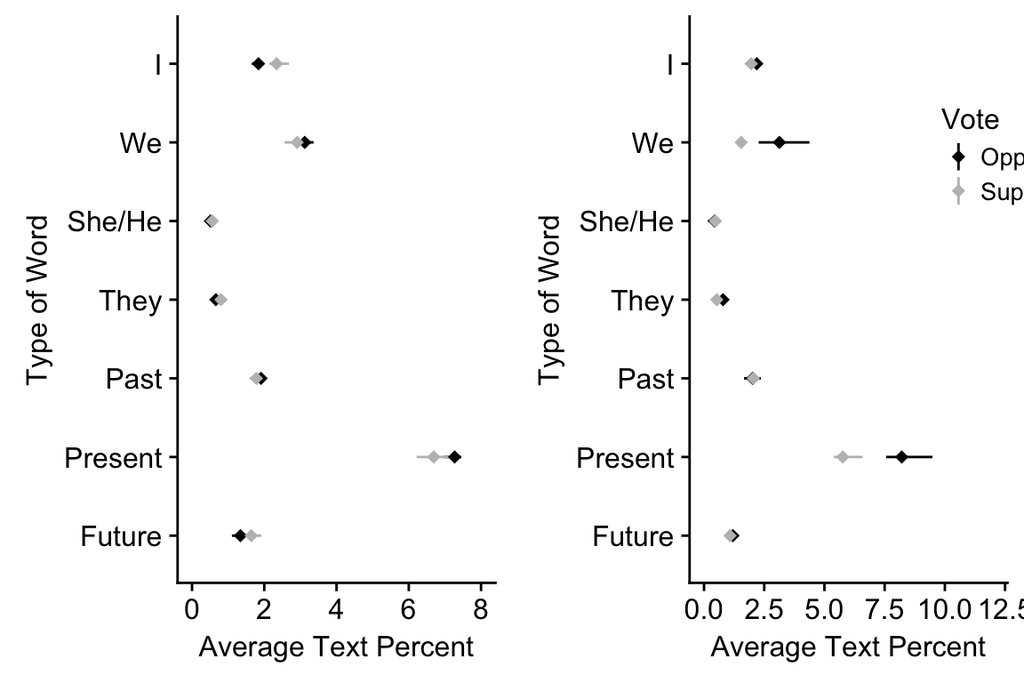

House (left) and Senate (right) bootstrapped means and 95% confidence interval for pronouns and verb tenses for Kosovo.

# Study 1A - Kosovo in the House

In early 1998, violence erupted in the Serbian region of Kosovo between ethnic Albanians and the Serbian government. A peace agreement later in the year lasted until the beginning of 1999 when several Albanian civilians were killed, prompting a resurrection of hostilities. When the Serbian government, namely President Slobodan Milosevic, failed to concede to allowing a NATO peacekeeping force in Kosovo during February 1999 negotiations, NATO authorized air strikes against Serbian targets. This decision subsequently prompted debate within the U.S. Congress as to the involvement of the U.S. military in NATO’s operations in Serbia and Kosovo [@Kim1999].

In this study, we examine this debate in the U.S. House of Representatives to determine if members of Congress who supported U.S. military involvement focused on people or events differently than those who opposed it.

# Method

Speeches made in the House of Representatives pertaining to the use of military force in Kosovo/Serbia were gathered from the Congressional Record available from the U.S. Government Publishing Office. In total, 210 speeches were collected. Speeches were limited to those made in the year preceding the vote on Senate Concurrent Resolution 21 made on April 28, 1999 to allow the President to conduct air and missile strikes against Yugoslavia (Serbia and Montenegro). This resolution failed in the House with 213-213 with 86% of Democrats supporting the resolution and 84% of Republicans opposing. These speeches were made by 156 unique speakers where where Republicans gave 108 speeches, Democrats gave 98 speeches, one Independent, one Non-Partisan, and two non-Representatives. Five speeches were excluded for no voting record. The average word count was 700.51 (*SD* = 814.04).

# Results

A forest plot of the results can be found in Figure @ref(fig:Kpic), and all descriptive statistics can be found in Table @ref(tab:Ktable). A small effect emerged for first-person singular pronouns and future tense verbs. Members of Congress who supported U.S. military action tended to use slightly more self-references and references to future actions.

# Study 1B - Kosovo in the Senate

In the second part of this study, we examined the Kosovo debate in the U.S. Senate to determine if the differences found in the first part of the study were also evident in the Senate.

# Method

Speeches were gathered in the same manner as in the first part of the study. All speeches made in the Senate in the year before the March 23, 1999 vote on Senate Concurrent Resolution 21. This resolution passed the Senate with 58 supporting and 41 opposing. All but 3 Democrats supported the resolution while 70% of Republicans opposed it. A total of 49 speeches were collected. These speeches were made by 25 unique senators with 12 speeches by Democrats and 37 by Republicans. The average word count for these speeches was 1413.14 (*SD* = 1076.37).

# Results

Analyses were conducted in the same manner as the first part of the study with bootstrapped means and CIs calculated for the seven categories marking attention. Results can be seen as a forest plot in Figure @ref(fig:Kpic) and Table @ref(tab:Ktable). Sizable differences were found in the use of first-person plural pronouns, third-person plural pronouns, and present-tense verbs. Senators who opposed U.S. military involvement in Kosovo tended make more group-references both to their own group and the outgroup. Senators opposed to the legislation also tended to make more reference to current actions.

# Discussion

# Study 2A - Iraq in the House

In this next study, we examined the debate preceding the congressional approval of the use of military force against Iraq. Regime change had been a long-standing position of the U.S. toward Iraq following the Gulf War; however serious military action was not considered until after the World Trade Center attacks on September 11, 2001. In 2002, President Bush declared Iraq part of an “axis of evil” in his State of the Union address. Iraq’s repeated violations of nuclear arms agreements, ties to terrorist organizations, and pursuit of weapons of mass destruction were argued by the Bush Administration to potentially pose a major threat to U.S. national security. This prompted the debate within Congress as to whether or not to approve President Bush’s request for military action [@Katzman2002]. These studies were used to determine if the findings from the first study extend to a different conflict. Specifically, in the first part of this study, we examined the debate in the House of Representatives to determine if members of Congress who supported taking military action used more self and future references.

# Method

Once again using the Government Publishing Office, we collected speeches given in the House of Representatives pertaining to the use of U.S. military force against Iraq in the three months before the vote on House Joint Resolution 114 on October 10, 2002. This bill passed the House with a 296-133 majority; with most Republicans supporting the measure and 60% of Democrats opposing. A total of 274 speeches were collected representing 233 unique speakers. Of these speeches, 155 speeches were made by Democrats, 119 were made by Republicans. The average word count of the speeches was 742.34 (*SD* = 1053.45). Four speeches were excluded for no voting record.

# Results

(#tab:Itable)

*Descriptive statistics for each dependent variable by chamber, region, and military support for Iraq*

| Chamber | Region | DV | $M_O$ | $SD_O$ | $M_S$ | $SD_S$ | $d_s$ | $d_s$ LL | $d_s$ UL |
| --- | --- | --- | --- | --- | --- | --- | --- | --- | --- |
| House | Iraq | I | 1.66 | 1.33 | 1.90 | 2.15 | -0.13 | -0.37 | 0.11 |
| House | Iraq | We | 3.01 | 1.61 | 2.76 | 1.37 | 0.17 | -0.07 | 0.41 |
| House | Iraq | She/He | 0.56 | 0.56 | 1.16 | 0.92 | -0.77 | -1.02 | -0.52 |
| House | Iraq | They | 0.46 | 0.51 | 0.49 | 1.36 | -0.03 | -0.27 | 0.21 |
| House | Iraq | Past | 1.33 | 1.14 | 1.52 | 1.12 | -0.17 | -0.41 | 0.07 |
| House | Iraq | Present | 6.33 | 1.96 | 6.35 | 1.62 | -0.01 | -0.25 | 0.23 |
| House | Iraq | Future | 1.49 | 0.81 | 1.35 | 0.61 | 0.20 | -0.04 | 0.44 |
| Senate | Iraq | I | 1.99 | 1.25 | 1.98 | 1.60 | 0.01 | -0.36 | 0.37 |
| Senate | Iraq | We | 2.47 | 0.97 | 2.61 | 1.15 | -0.13 | -0.50 | 0.23 |
| Senate | Iraq | She/He | 0.60 | 0.47 | 1.20 | 0.62 | -1.03 | -1.42 | -0.65 |
| Senate | Iraq | They | 0.49 | 0.32 | 0.56 | 0.40 | -0.19 | -0.55 | 0.18 |
| Senate | Iraq | Past | 1.39 | 0.63 | 1.84 | 1.22 | -0.42 | -0.79 | -0.05 |
| Senate | Iraq | Present | 6.51 | 2.16 | 6.93 | 2.07 | -0.20 | -0.57 | 0.16 |
| Senate | Iraq | Future | 1.47 | 0.59 | 1.29 | 0.53 | 0.32 | -0.05 | 0.68 |

*Note.* Confidence intervals for $d_s$ were calculated using non-central $t$ distribution. O = Oppose, S = Support, LL = Lower Limit, UL = Upper Limit.

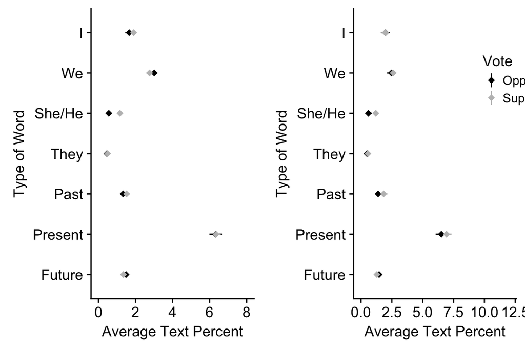

House (left) and Senate (right) bootstrapped means and 95% confidence interval for pronouns and verb tenses for Iraq.

As in the first study, bootstrapped means and confidence intervals as well as effect sizes (Cohen’s *d*) were calculated for speeches of those supporting the measure versus those opposing the measure for the following LIWC categories: first-person singular (*I*), first-person plural (*we*), third-person singular (*he*, *she*), third-person plural (*they*), past-tense, present-tense, and future tense. Results can be seen as a forest plot in Figure @ref(fig:Ipic) and in Table @ref(tab:Itable). A sizable difference emerged in the use of third-person singular pronouns. Representatives who supported the military measure used other references at a higher rate than those who opposed taking military action.

# Study 2B - Iraq in the Senate

In the second part of this study, we examined the debate in the Senate. We wished to determine if, like senators who opposed military action in Kosovo, senators who opposed action against Iraq used more group references as well as more reference to current events.

# Method

In this part of the study, speeches from the Senate were gathered for the 6 months before the Senate vote on House Joint Resolution 114 conducted on October 11, 2002. The bill passed with a 77-23 majority. All but one Republican supported the measure as did 58% of Democrats. In total, 138 speeches were collected representing 85 unique speakers. Of these speeches, 74 were given by Democrats and 64 by Republicans. The average word count for these speeches were 1991.23 (*SD* = 1671.70).

# Results

Analyses were conducted in the same manner as the first part of the study to determine differences between supporters and opponents of military action in Iraq in terms of the use of first-person singular (*I*), first-person plural (*we*), third-person singular (*he*, *she*), third-person plural (*they*), past-tense, present-tense, and future tense. Figure @ref(fig:Ipic) displays these results as a forest plot, and all values are in Table @ref(tab:Itable). A large difference was found in the use of third-person singular pronouns as well as a smaller difference in the use of past tense verbs. Senators who supported the military measure tended to use more other references as well so as to be slightly more oriented to past events.

# Discussion

# Study 3 - Libya in the House

In this final study, we examine the debate in the House of Representatives surrounding U.S. military involvement in Libya during its revolution. In February 2011, a revolt against Libyan dictator, Muammar Qaddafi, prompted the intervention of NATO when Qaddafi violently suppressed all opposition. The involvement of NATO lead to debate within Congress as to the exact role of the U.S. in military operations in Libya and the extent of U.S involvement [@Blanchard2011]. In examining this debate, we wished to determine if the language of those who supported or opposed military action was similar to those of either of the first two studies.

# Method

In this final study, the Congressional Record was searched for speeches given in the House of Representatives pertaining to the debate of the authorization of military action against Libya in the three months before the vote on House Joint Resolution 68 on June 24, 2011. The bill failed in the House 123-295. All but 14 Republicans voted against the resolution while 60% of Democrats supported the resolution. A total of 104 speeches were collected representing 76 unique speakers. Democrats made 53 of these speeches while 51 speeches were made by Republicans. The average word count for these speeches was 465.93 (*SD* = 477.41). As the resolution failed in the House, it was not possible to examine this debate in the Senate. Five speeches were excluded for no voting record.

# Results

(#tab:Ltable)

*Descriptive statistics for each dependent variable by chamber, region, and military support for Libya*

| Chamber | Region | DV | $M_O$ | $SD_O$ | $M_S$ | $SD_S$ | $d_s$ | $d_s$ LL | $d_s$ UL |
| --- | --- | --- | --- | --- | --- | --- | --- | --- | --- |
| House | Libya | I | 2.47 | 1.66 | 2.31 | 1.13 | 0.11 | -0.31 | 0.53 |
| House | Libya | We | 3.08 | 2.22 | 2.89 | 1.87 | 0.09 | -0.33 | 0.51 |
| House | Libya | She/He | 0.61 | 0.83 | 0.64 | 0.85 | -0.04 | -0.46 | 0.38 |
| House | Libya | They | 0.60 | 0.91 | 0.64 | 0.72 | -0.04 | -0.46 | 0.37 |
| House | Libya | Past | 1.63 | 1.18 | 2.16 | 2.22 | -0.33 | -0.75 | 0.09 |
| House | Libya | Present | 7.42 | 2.78 | 7.39 | 4.69 | 0.01 | -0.41 | 0.42 |
| House | Libya | Future | 1.19 | 0.75 | 1.25 | 0.80 | -0.07 | -0.49 | 0.34 |

*Note.* Confidence intervals for $d_s$ were calculated using non-central $t$ distribution. O = Oppose, S = Support, LL = Lower Limit, UL = Upper Limit.

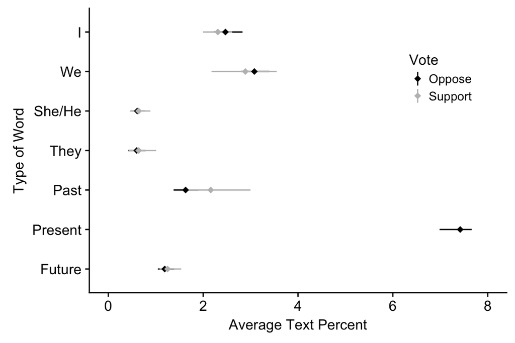

As in the first two studies, analyses consisted on comparing the bootstrapped means, CIs, and effects sizes for those who supported the military measure versus those who opposed it on the following linguistic measures: first-person singular (*I*), first-person plural (*we*), third-person singular (*he*, *she*), third-person plural (*they*), past-tense, present-tense, and future tense. These results are displayed in Figure @ref(fig:Lpic) as a forest plot and in Table @ref(tab:Ltable). No differences emerged on any measure.

# Discussion

# General Discussion